# Writing exercises in R

Marc Choisy

2019-02-18

The **literate programming** ability of Rmarkdown makes it a great language for **reproducible research**. It is also used for many other applications (such as writing books, websites, blogs, apps, etc…). One of them that I’ve found particularly useful is for teaching, when the tutor needs to write exercises of which (s)he wants to control the visibility of the solutions in a way or another.

[output not shown]

The way I work as a tutor is that I write the Rmarkdown document, then compile it to an HTML document that I host on a web server (for example [RPubs](http://rpubs.com)), of which I provide the URL to the student. Links to examples and templates are also provided below.

## Option 1: the tutor controls the visibility of the solutions

When I, as the tutor, want to keep full control of the visibility of the solution, I do it thanks to the chunk option `include` of the R code chunks of the Rmarkdown document. For example, the following Rmarkdown code:

````markdown
**Exercise 1:** Define `x` and `y` vectors as below
```{r exercise_1}
set.seed(123523458)
x <- 1:10
y <- sample(x)
```
and plot `y` as a function of `x`.

**Solution to Exercise 1:**
```{r solution_1, include = FALSE}
plot(x, y)
```
````

will produce the following HTML output where the solution is not visible:

**Exercise 1:** Define `x` and `y` vectors as below

```r
set.seed(123523458)
x <- 1:10
y <- sample(x)
```

and plot `y` as a function of `x`.

**Solution to Exercise 1:**

Now, if I decide to show the solution, I just have to switch the `include` chunck option from `FALSE` to `TRUE`:

````markdown
**Exercise 1:** Define `x` and `y` vectors as below
```{r exercise_1}
set.seed(123523458)
x <- 1:10
y <- sample(x)
```
and plot `y` as a function of `x`.

**Solution to Exercise 1:**
```{r solution_1, include = TRUE}
plot(x, y)
```
````

which produces the following HTML output after recompilation:

**Exercise 1:** Define `x` and `y` vectors as below

```r
set.seed(123523458)
x <- 1:10
y <- sample(x)
```

and plot `y` as a function of `x`.

**Solution to Exercise 1:**

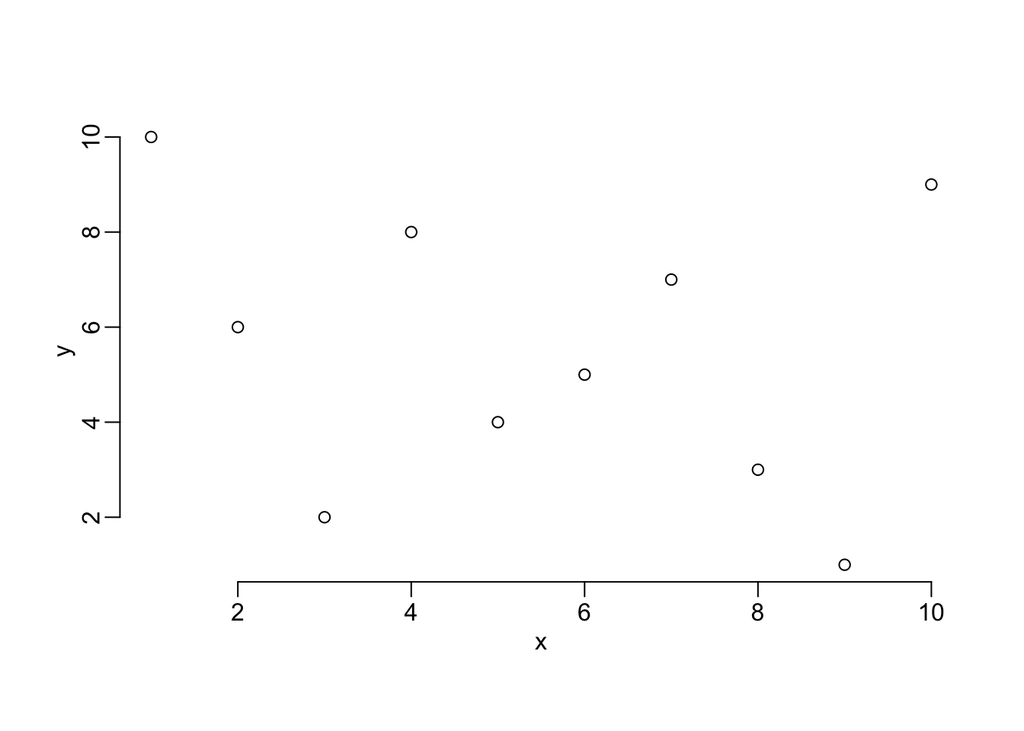

```r
plot(x, y)
```

Et voilà!

### Showing several solutions at once

You may have several exercises, each with its solution. If you decide to show several solutions at once, all you have to do is define a boolean variable and use the value of this variable for the value of the `include` option of all the chuncks you want to control the same way. Good practice is to define the boolean variable in a chunk at the beginning of the Rmarkdown document that contains all the settings of the document. Here is an example:

````markdown
```{r settings, include = FALSE}
switch1 <- FALSE
```

**Exercise 1:** Define `x` and `y` vectors as below
```{r exercise_1}
set.seed(123523458)
x <- 1:10
y <- sample(x)
```
and plot `y` as a function of `x`.

**Solution to Exercise 1:**
```{r solution_1, include = switch1}
plot(x, y)
```

**Exercise 2:** Make a linear model `y` as a function of `x`.

**Solution to Exercise 2:**
```{r solution_2, include = switch1}
model <- lm(y ~ x)
```

**Exercise 3:** Make a plot of `y` as a function of `x`, together with the
linear model

**Solution to Exercise 3:**
```{r solution_3, include = FALSE}
plot(x, y)
abline(model)
```
````

That produces the following HTML output:

**Exercise 1:** Define `x` and `y` vectors as below

```r
set.seed(123523458)
x <- 1:10
y <- sample(x)
```

and plot `y` as a function of `x`.

**Solution to Exercise 1:**

**Exercise 2:** Make a linear model `y` as a function of `x`.

**Solution to Exercise 2:**

**Exercise 3:** Make a plot of `y` as a function of `x`, together with the linear model

**Solution to Exercise 3:**

where none of the solutions is displayed. If you want to show solutions to exercises 1 and 2 all at once, all you have to do is change the value of the `switch1` boolean variable in the settings chunk as so:

````markdown
```{r settings, include = FALSE}
switch1 <- TRUE
```
````

Now, when you recompile the document, the HTML output looks like:

**Exercise 1:** Define `x` and `y` vectors as below

```r
set.seed(123523458)
x <- 1:10
y <- sample(x)
```

and plot `y` as a function of `x`.

**Solution to Exercise 1:**

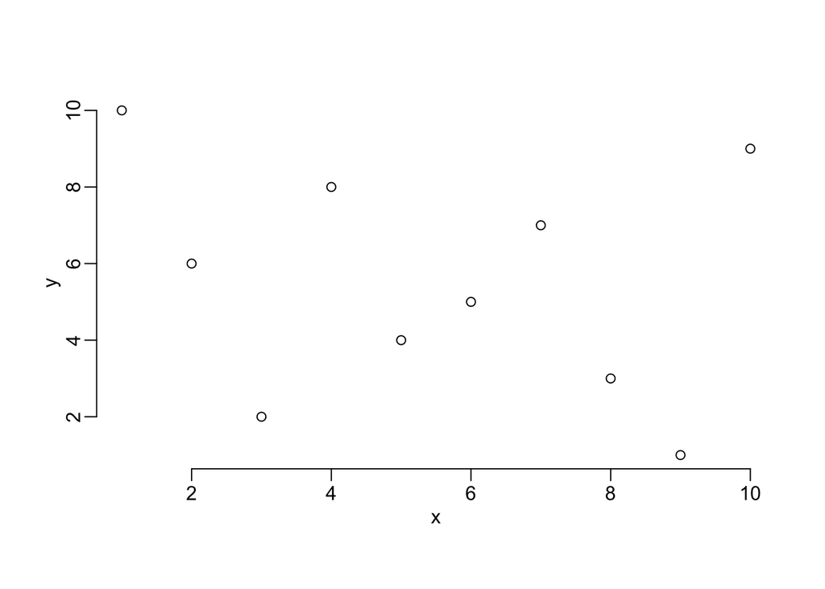

```r
plot(x, y)
```

**Exercise 2:** Make a linear model `y` as a function of `x`.

**Solution to Exercise 2:**

```r
model <- lm(y ~ x)
```

**Exercise 3:** Make a plot of `y` as a function of `x`, together with the linear model

**Solution to Exercise 3:**

where the solutions to both exercises 1 and 2 are displayed but not the solution to exercise 3.

## Option 2: the student can unhide the solution him(her)self

If seeing the solution of the exercises is let to the student’s decision, then you can opt for an interactive HTML document, using the `code_folding` option of the YAML header of the Rmarkdown document, as so:

```markdown
---
title: "R exercises"
output:
  html_document:
    code_folding: hide
---
```

Note that here, we’ve even set the `code_folding` option to the `hide` value which means that, by default, the R code of all the chunks will be hidden and the user can decide to reveal all or each of them separately. If the `code_folding` was set to `show` instead, then, by default, the R code of all the chunks will have been visible and the user could have decided to hide them, again, all of them at once, or each of them separately. An example of the first option (`code_folding: hide`) is visible [here](http://rpubs.com/choisy/code_folding_hide) (with source code [here](http://bit.ly/codefoldinghide)) and an example of the second option (`code_folding: show`) is visible [here](http://rpubs.com/choisy/code_folding_show) (with source code [here](http://bit.ly/codefoldingshow)). Note by the way that the output of the R code chunks are never hidden.

## Option 3: flexibility with JavaScript

Because option 2 makes use of an option of the YAML header of the Rmarkdown document, it is impossible to define different behaviors on different R code chunks. As of February 2019, the only way to the combine user control of option 2 with the by-chunk definition of option 1 is to make use of JavaScript code in the Rmarkdown document as suggested [here](https://stackoverflow.com/questions/37755037/how-to-add-code-folding-to-output-chunks-in-rmarkdown-html-documents/37839683#37839683) (it seems that an Rmarkdown solution to do so is under development at the moment). What you have to do is

#### 1. include the following javascript code at the end of the Rmarkdown document:

```javascript
<script>
  $(".toggle").click(function() {
    $(this).toggleClass("open");
  });
</script>
```

#### 2. write a CCS file that contains the following CSS code:

```css
.toggle {
  height: 1.55em;
  overflow-y: hidden;
}
.toggle.open {
  height: auto;
}
```

This CCS code defines the style of the button. In this example, let’s call this file `styles.css` and make a link to it in the YAML header of the Rmarkdown document:

```markdown
---
title: "R exercises"
output:
  html_document:
    css: styles.css
---
```

#### 3. add buttons to your code wherever needed as so:

````markdown
**Exercise 1:** Define `x` and `y` vectors as below

```r
set.seed(123523458)
x <- 1:10
y <- sample(x)
```
and plot `y` as a function of `x`.

<div class="toggle"><button>Solution</button>
```{r}
plot(x, y)
```
</div><br>
````

The above example includes a button that, when clicked on, shows the R code `plot(x, y)` together with its output. (Note that it is a slightly different behaviour from what we had with the YAML `code_folding` option where only the R code was hidden, not its output). See an example [here](http://rpubs.com/choisy/code_folding_js) and its source code [here](http://bit.ly/codefoldingjs) for which the corresponding CSS file is [here](http://bit.ly/foldingcodecss) and should be saved in a file named `styles.css` in the save directory as the Rmarkdown file before compilation. Note also that the buttons could braket any lines, these lines containing chunks or simply text, or actually anything.